# Dimension Reduction for Taxonomy Data – Change Analysis

This document takes the final UMAP dimension reduction results and tries to find groups of participants that are similar in (directional) change between the timepoints.

## Data preparation and UMAP estimation

```r
library(sauerkrautTaxonomyBuddy)
library(SummarizedExperiment) # microbiome analysis
library(mia)                  # microbiome analysis
library(vegan)                # (dis)similarity measures

library(scater)     # dimension reduction and visualizations
library(mgcv)       # estimate smooth surfaces with gam()
library(mgcViz)     # visualize gam models

library(dplyr)      # data handling
library(tidyr)      # data transformation
library(ggplot2)    # data visualization
library(patchwork)  # joint ggplots
library(kableExtra) # table printing

# set ggplot2 theme
theme_set(
  theme_minimal() +
    theme(plot.title       = element_text(hjust = 0.5),
          plot.subtitle    = element_text(hjust = 0.5),
          panel.grid.minor = element_blank())
)
```

```r
define_dataPaths()
```

```r
tse <- readAndPrepare_mainTaxonomicData(path_groupInfoRdata               = path_groupInfoRdata,
                                        path_participantRdata             = path_participantRdata,
                                        path_samplesIDxlsx                = path_samplesIDxlsx,
                                        path_dietInfoCsv                  = path_dietInfoCsv,
                                        path_nutrientInfoCsv              = path_nutrientInfoCsv,
                                        path_bloodMetabolomeXlsx          = path_bloodMetabolomeXlsx,
                                        path_stoolMetabolomeXlsx          = path_stoolMetabolomeXlsx,
                                        path_T4questXlsx                  = path_T4questXlsx,
                                        path_stoolInfoXlsx                = path_stoolInfoXlsx,
                                        path_bodyMeasuresXlsx             = path_bodyMeasuresXlsx,
                                        path_absTaxonomyData              = path_absTaxonomyData,
                                        path_relTaxonomyData              = path_relTaxonomyData,
                                        path_sampleLookupXlsx             = path_sampleLookupXlsx,
                                        path_krautLookupXlsx              = path_krautLookupXlsx,
                                        path_bloodMarkerBostonRdata       = path_bloodMarkerBostonRdata,
                                        path_bloodMarkerZentrallaborRdata = path_bloodMarkerZentrallaborRdata,
                                        path_bloodMarkerBostonXlsx        = path_bloodMarkerBostonXlsx,
                                        path_bloodMarkerZentrallaborXlsx  = path_bloodMarkerZentrallaborXlsx,
                                        aggregation_level                 = "species",
                                        exclude_sickParticipants          = "taxonomy paper")

# add further features to colData(tse)
tse <- tse_addTaxaFeatures(tse          = tse,
                           assay_relAbd = "relAbd")

# save colData() as a separate data.frame
dat <- tse %>% colData() %>% as.data.frame()
```

```r
# add strata information
dat <- dat %>%
  mutate(age_cat        = case_when(age < 50 ~ paste0(min(age), "-49"),
                                    TRUE     ~ paste0("50-", max(age))),
         age_cat        = factor(age_cat),
         bmi_cat        = case_when(bmi_t0 < 25 ~ paste0("[", floor(min(bmi_t0)), ", 25)"),
                                    TRUE        ~ paste0("[25, ", ceiling(max(bmi_t0)), "]")),
         bmi_cat        = factor(bmi_cat))
```

```r
set.seed(2025)
tse <- tse %>% runUMAP(name = "UMAP", exprs_values = "relAbd")

dat_UMAP <- tse %>%
  reducedDim("UMAP") %>%
  dplyr::bind_cols(dat)
```

## base UMAP plot

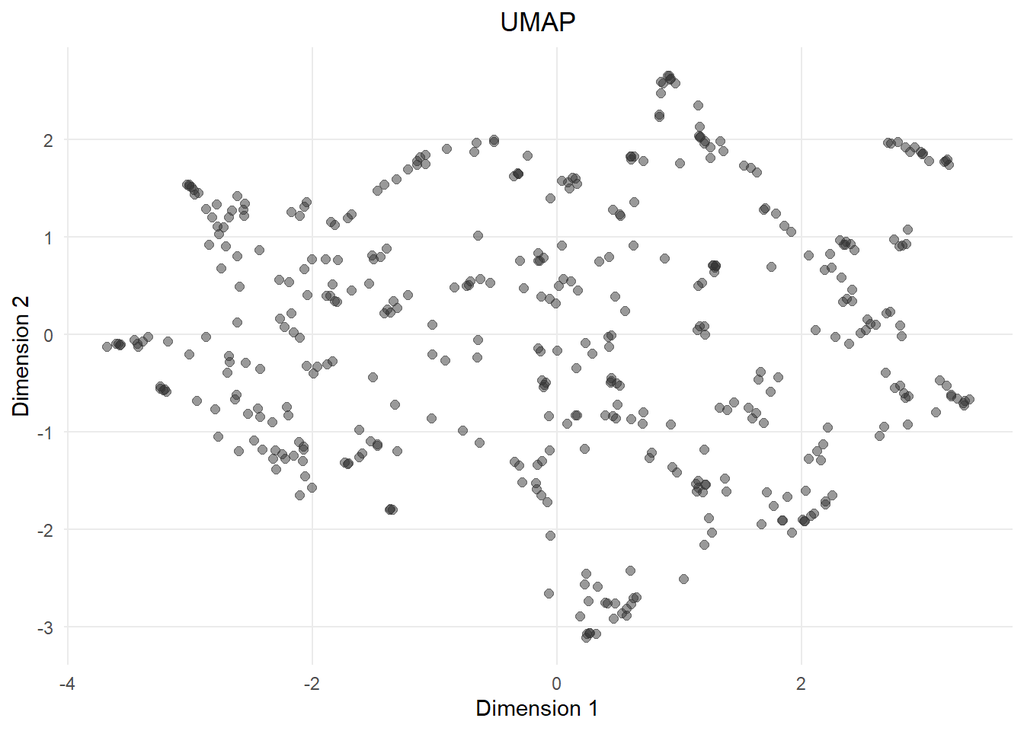

```r
plot_list <- plot_dimReduction(tse                = tse,
                               dimReduction_name  = "UMAP",
                               assay              = "relAbd",
                               taxRank_dominance  = "species",
                               taxRank_topNfocus  = 13)
plot_list$gg_basePlot
```

## Calculate (directional) changes based on UMAP coordinates

```r
# put the data preparation in a function, s.t. it's easily applicable also to subgroups in dat_UMAP
create_changeDat <- function(dat_UMAP) {
  # create the location dataset
  dat_change <- dat_UMAP %>%
    dplyr::rename(x = UMAP1,
                  y = UMAP2) %>%
    select(participant_id, intervention, timepoint, x, y) %>%
    pivot_wider(id_cols = participant_id, names_from = timepoint, values_from = c("x", "y")) %>%
    arrange(participant_id)

  # add the directional change variables
  dat_change <- dat_change %>%
    mutate(xChange_T1toT2           = x_T2 - x_T1,
           yChange_T1toT2           = y_T2 - y_T1,
           totalAbsChange_T1toT2    = abs(xChange_T1toT2) + abs(yChange_T1toT2),
           totalAvgAbsChange_T1toT2 = totalAbsChange_T1toT2 / 2,
           xChange_T2toT3           = x_T3 - x_T2,
           yChange_T2toT3           = y_T3 - y_T2,
           totalAbsChange_T2toT3    = abs(xChange_T2toT3) + abs(yChange_T2toT3),
           totalAvgAbsChange_T2toT3 = totalAbsChange_T2toT3 / 2,
           xChange_T3toT4           = x_T4 - x_T3,
           yChange_T3toT4           = y_T4 - y_T3,
           totalAbsChange_T3toT4    = abs(xChange_T3toT4) + abs(yChange_T3toT4),
           totalAvgAbsChange_T3toT4 = totalAbsChange_T3toT4 / 2)

  if ("x_T5" %in% colnames(dat_change)) {
    dat_change <- dat_change %>%
      mutate(xChange_T4toT5           = x_T5 - x_T4,
             yChange_T4toT5           = y_T5 - y_T4,
             totalAbsChange_T4toT5    = abs(xChange_T4toT5) + abs(yChange_T4toT5),
             totalAvgAbsChange_T4toT5 = totalAbsChange_T4toT5 / 2)
  } else {
    dat_change <- dat_change %>%
      mutate(xChange_T4toT5           = NA,
             yChange_T4toT5           = NA,
             totalAbsChange_T4toT5    = NA,
             totalAvgAbsChange_T4toT5 = NA)
  }

  # add the overall change variable
  dat_change <- dat_change %>%
    mutate(n_observedChanges       = as.numeric(!is.na(totalAbsChange_T1toT2)) + as.numeric(!is.na(totalAbsChange_T2toT3)) +
             as.numeric(!is.na(totalAbsChange_T3toT4)) + as.numeric(!is.na(totalAbsChange_T4toT5))) %>%
    rowwise() %>%
    mutate(totalAbsChange_total    = sum(c(totalAbsChange_T1toT2, totalAbsChange_T2toT3, totalAbsChange_T3toT4, totalAbsChange_T4toT5), na.rm = TRUE),
           totalAvgAbsChange_total = totalAbsChange_total / (2*n_observedChanges),
           xAbsChange_total        = sum(abs(c(xChange_T1toT2, xChange_T2toT3, xChange_T3toT4, xChange_T4toT5)), na.rm = TRUE),
           xAvgAbsChange_total     = xAbsChange_total / n_observedChanges,
           yAbsChange_total        = sum(abs(c(yChange_T1toT2, yChange_T2toT3, yChange_T3toT4, yChange_T4toT5)), na.rm = TRUE),
           yAvgAbsChange_total     = yAbsChange_total / n_observedChanges)

  # add a avgAbsBaselineChange variable, containing the average pairwise change between T1, T3, T5, averaged over x and y
  dat_change <- dat_change %>%
    rowwise() %>%
    mutate(xChange_T1toT3 = x_T3 - x_T1,
           xChange_T1toT5 = x_T5 - x_T1,
           xChange_T3toT5 = x_T5 - x_T3,
           yChange_T1toT3 = y_T3 - y_T1,
           yChange_T1toT5 = y_T5 - y_T1,
           yChange_T3toT5 = y_T5 - y_T3,
           avgAbsBaselineChange = sum(abs(c(xChange_T1toT3, xChange_T1toT5, xChange_T3toT5,
                                            yChange_T1toT3, yChange_T1toT5, yChange_T3toT5)), na.rm = TRUE) / 6,
           avgAbsBaselineChange_T1toT3 = sum(abs(c(xChange_T1toT3, yChange_T1toT3)), na.rm = TRUE) / 2,
           avgAbsBaselineChange_T1toT5 = sum(abs(c(xChange_T1toT5, yChange_T1toT5)), na.rm = TRUE) / 2,
           avgAbsBaselineChange_T3toT5 = sum(abs(c(xChange_T3toT5, yChange_T3toT5)), na.rm = TRUE) / 2)

  dat_change
}
```

```r
dat_change <- create_changeDat(dat_UMAP)

# create a long dataset for plotting
timepoints <- c("T2","T3","T4","T5")
dat_plot <- data.frame(participant_id = rep(dat_change$participant_id, each = length(timepoints)),
                       timepoint      = rep(timepoints, times = nrow(dat_change)),
                       xCoord         = c(dat_change$x_T2, dat_change$x_T3, dat_change$x_T4, dat_change$x_T5),
                       yCoord         = c(dat_change$y_T2, dat_change$y_T3, dat_change$y_T4, dat_change$y_T5),
                       xCoord_change  = c(dat_change$xChange_T1toT2, dat_change$xChange_T2toT3, dat_change$xChange_T3toT4, dat_change$xChange_T4toT5),
                       yCoord_change  = c(dat_change$yChange_T1toT2, dat_change$yChange_T2toT3, dat_change$yChange_T3toT4, dat_change$yChange_T4toT5),
                       avgAbs_change  = c(dat_change$totalAvgAbsChange_T1toT2, dat_change$totalAvgAbsChange_T2toT3,
                                          dat_change$totalAvgAbsChange_T3toT4, dat_change$totalAvgAbsChange_T4toT5))
```

# Description of changes in UMAP

The following plots visualize the changes *leading to the timepoint*. For example for a measurement taken at T4 this corresponds to the *change from T3 to T4*.

##### Overall change

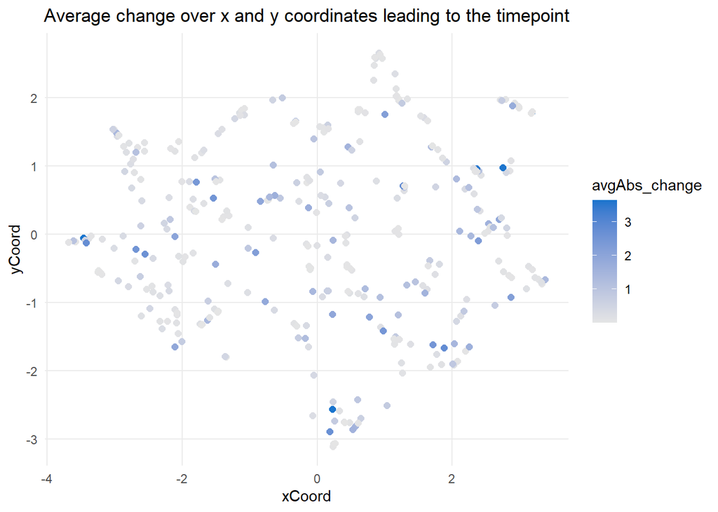

```r
# overall change
ggplot(dat_plot, aes(x = xCoord, y = yCoord, col = avgAbs_change)) +
  geom_point(size = 2) +
  scale_color_gradient2(low = "firebrick3", mid = "gray90", high = "dodgerblue3") +
  ggtitle("Average change over x and y coordinates leading to the timepoint")
```

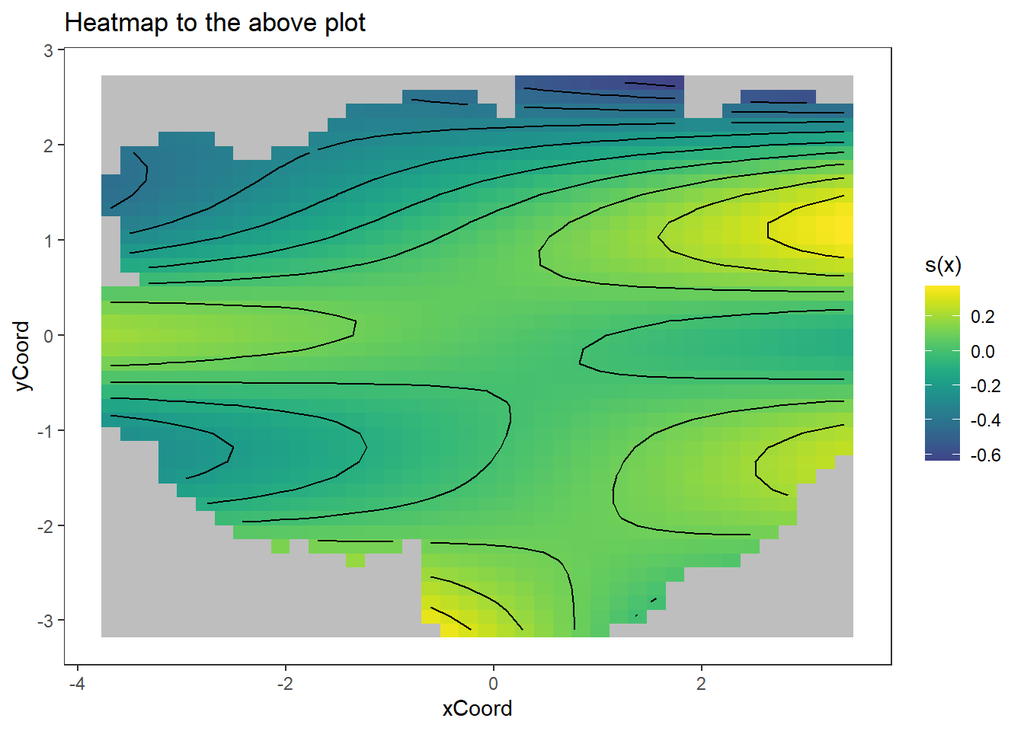

```r
# heatmap for overall change
m <- gam(avgAbs_change ~ te(xCoord, yCoord), data = dat_plot)
m %>% getViz() %>% sm(1) %>% plot() + ggtitle("Heatmap to the above plot")
```

##### Changes in x and y coordinates

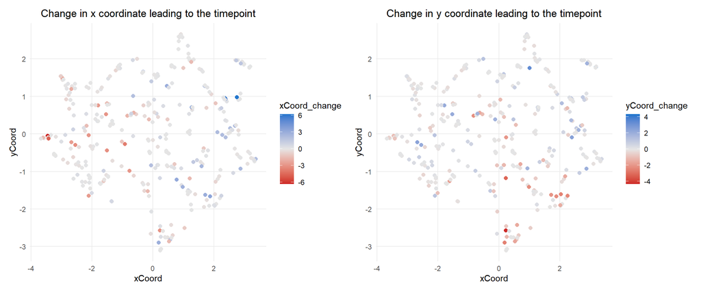

```r
# changes in x and y coordinates
gg_xChange <- ggplot(dat_plot, aes(x = xCoord, y = yCoord, col = xCoord_change)) +
  geom_point(size = 2) +
  scale_color_gradient2(low = "firebrick3", mid = "gray90", high = "dodgerblue3") +
  ggtitle("Change in x coordinate leading to the timepoint")

gg_yChange <- ggplot(dat_plot, aes(x = xCoord, y = yCoord, col = yCoord_change)) +
  geom_point(size = 2) +
  scale_color_gradient2(low = "firebrick3", mid = "gray90", high = "dodgerblue3") +
  ggtitle("Change in y coordinate leading to the timepoint")

gg_xChange + gg_yChange
```

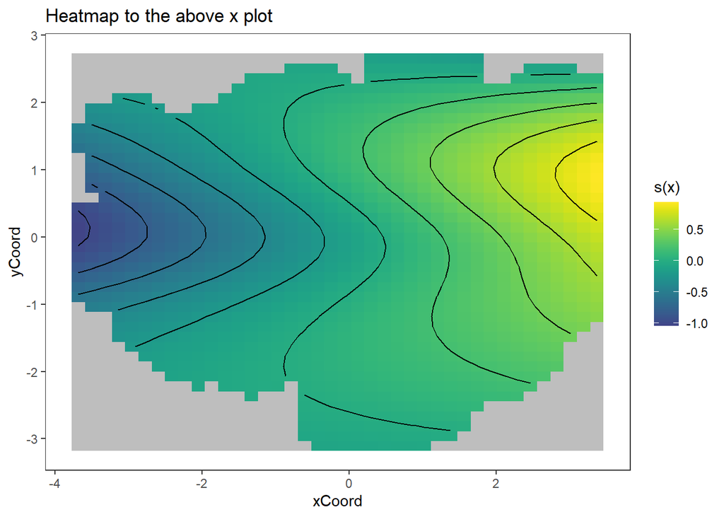

```r
# heatmap for change in x
mx <- gam(xCoord_change ~ te(xCoord, yCoord), data = dat_plot)
mx %>% getViz() %>% sm(1) %>% plot() + ggtitle("Heatmap to the above x plot")
```

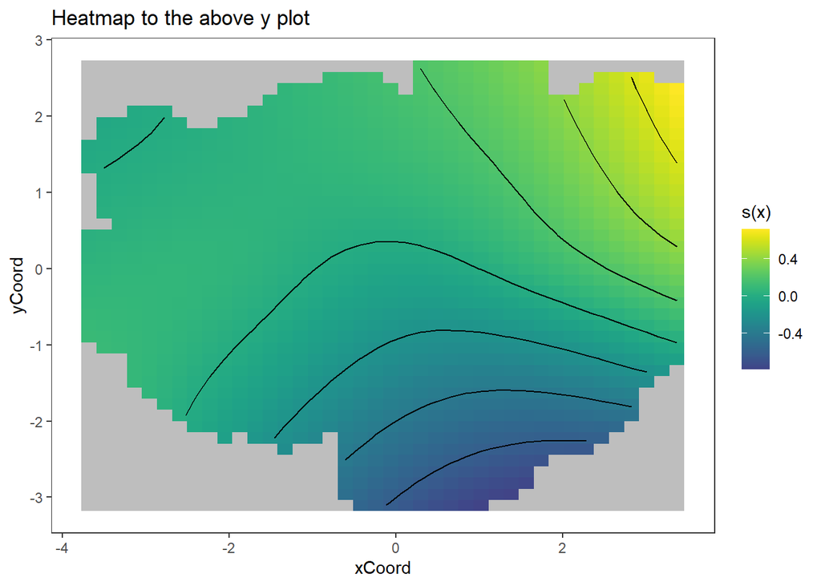

```r
# heatmap for change in y
my <- gam(yCoord_change ~ te(xCoord, yCoord), data = dat_plot)
my %>% getViz() %>% sm(1) %>% plot() + ggtitle("Heatmap to the above y plot")
```

# Regression models on UMAP coordinate change

## Model on average absolute change

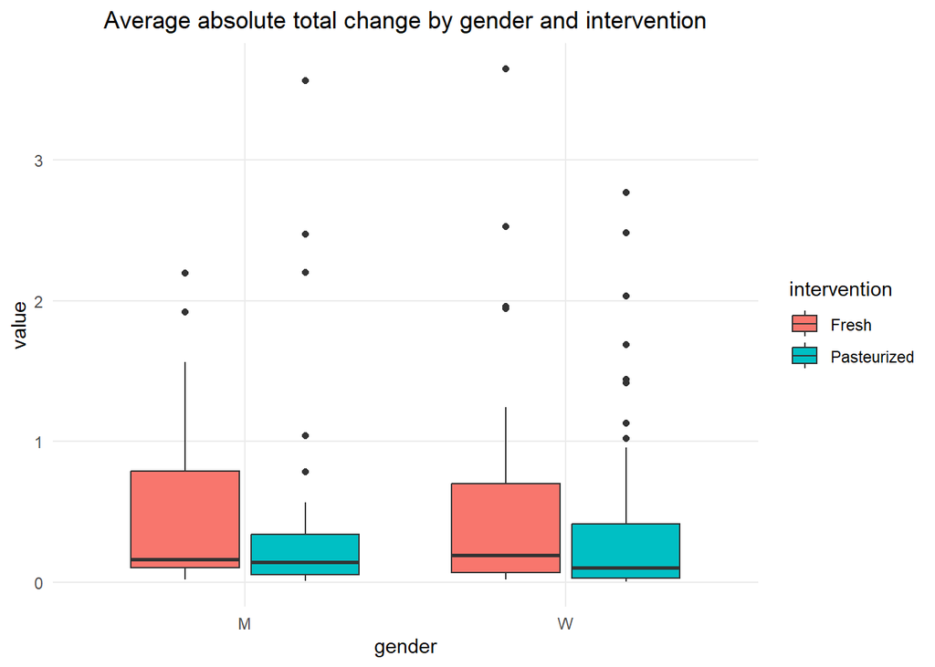

```r
# data preparation
dat_modelTotal <- dat_change %>%
  select(participant_id, starts_with("totalAvgAbsChange"), starts_with("avgAbsBaselineChange")) %>%
  pivot_longer(cols = starts_with("totalAvgAbsChange"), names_to = "parameter") %>%
  filter(grepl("T1toT2", parameter) | grepl("T3toT4", parameter),
         !is.na(value)) %>%
  dplyr::left_join(dat %>% distinct(participant_id, .keep_all = TRUE) %>% select(participant_id, gender, age, bmi_t0, diet_veggie, starts_with("dailyConsumption"), starts_with("diversity")),
                   by = "participant_id") %>%
  mutate(timepoint = substr(parameter, nchar(parameter) - 1, nchar(parameter))) %>%
  dplyr::left_join(dat %>% select(participant_id, timepoint, intervention, starts_with("dominant_species")),
                   by = c("participant_id", "timepoint"))

# description
ggplot(dat_modelTotal, aes(x = gender, y = value, fill = intervention)) +
  geom_boxplot() +
  ggtitle("Average absolute total change by gender and intervention")
```

```r
# model estimation
mTotal <- gam(value ~ intervention + gender + age + bmi_t0 + diversity_shannon + s(participant_id, bs = "re"),
              data = dat_modelTotal)

# results
APCtools::create_modelSummary(list(mTotal))[[1]] %>% kable_styling()
```

| model | param | coef | se | CI_lower | CI_upper | pvalue |
| --- | --- | --- | --- | --- | --- | --- |
| model 1 | (Intercept) | 1.22 | 0.93 | -0.60 | 3.05 | - |
| model 1 | interventionPasteurized | -0.12 | 0.10 | -0.32 | 0.09 | 0.2671 |
| model 1 | genderW | 0.01 | 0.13 | -0.24 | 0.26 | 0.9413 |
| model 1 | age | 0.00 | 0.00 | -0.01 | 0.01 | 0.7432 |
| model 1 | bmi_t0 | -0.01 | 0.02 | -0.06 | 0.03 | 0.5011 |
| model 1 | diversity_shannon | -0.07 | 0.20 | -0.47 | 0.33 | 0.7227 |

##### Estimate the same model with T1 vs. T3 as baseline reference

Dominant species reference category is Blautia wexlerae.

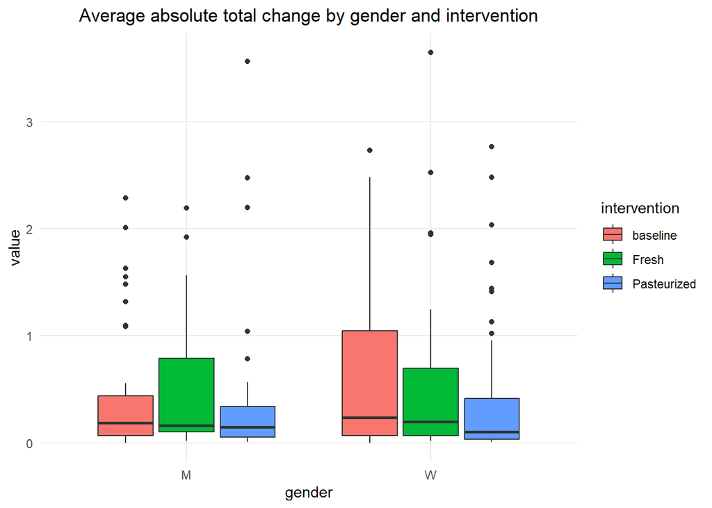

```r
# data preparation
dat_modelTotal_T1toT3 <- dat_change %>%
  select(participant_id, starts_with("avgAbsBaselineChange")) %>%
  pivot_longer(cols = starts_with("avgAbsBaselineChange"), names_to = "parameter") %>%
  filter(grepl("T1toT3", parameter), !is.na(value)) %>%
  dplyr::left_join(dat %>% distinct(participant_id, .keep_all = TRUE) %>% select(participant_id, gender, age, bmi_t0, starts_with("diversity"), dominant_species),
                   by = "participant_id") %>%
  mutate(timepoint    = "T3",
         intervention = "baseline")

tab_domSpec    <- sort(table(dat$dominant_species), decreasing = TRUE)
domSpec_catVec <- names(tab_domSpec[tab_domSpec >= 15]) %>% append("other")
dat_modelTotal_test <- dat_modelTotal %>%
  dplyr::bind_rows(dat_modelTotal_T1toT3) %>%
  mutate(domSpec_cat = case_when(dominant_species %in% domSpec_catVec ~ dominant_species,
                                 TRUE                                 ~ "other"),
         domSpec_cat = factor(domSpec_cat, levels = domSpec_catVec))

# description
ggplot(dat_modelTotal_test, aes(x = gender, y = value, fill = intervention)) +
  geom_boxplot() +
  ggtitle("Average absolute total change by gender and intervention")
```

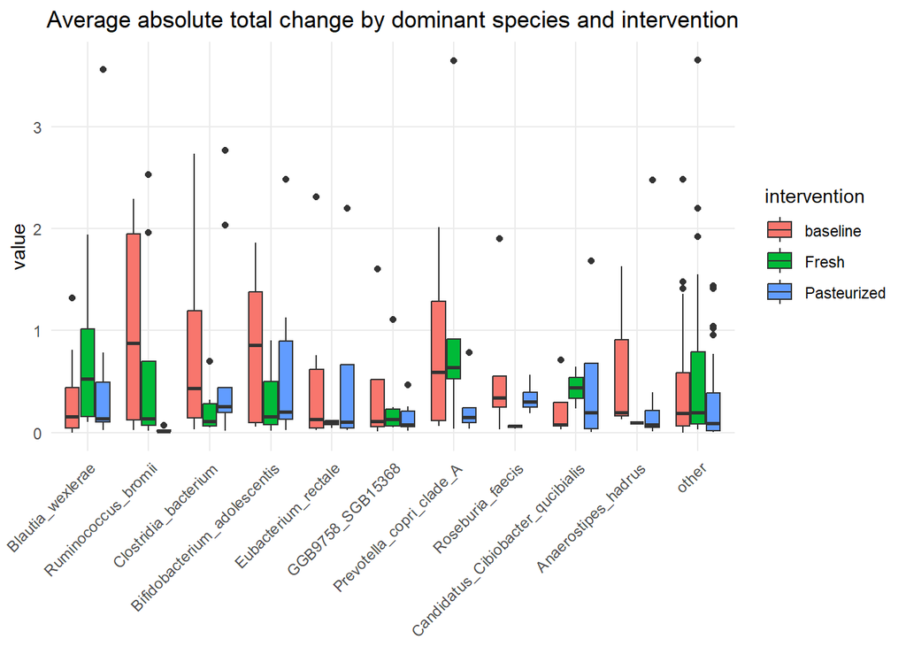

```r
ggplot(dat_modelTotal_test, aes(x = domSpec_cat, y = value, fill = intervention)) +
  geom_boxplot() +
  ggtitle("Average absolute total change by dominant species and intervention") +
  theme(axis.text.x  = element_text(angle = 45, hjust = 1),
        axis.title.x = element_blank())
```

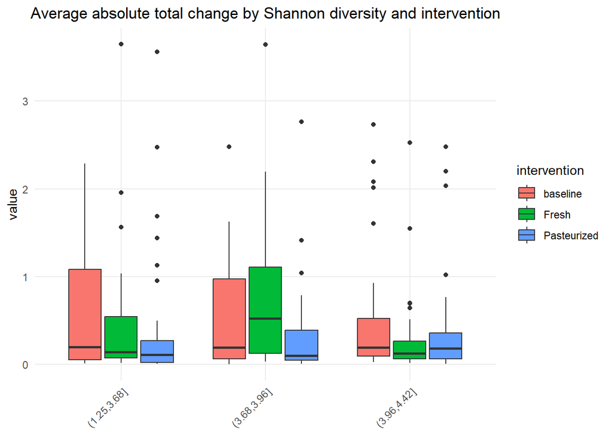

```r
dat_modelTotal_test %>%
  mutate(divSh_cat = cut(diversity_shannon, breaks = c(1.25, quantile(diversity_shannon, probs = c(1,2,3)/3)))) %>%
  ggplot(aes(x = divSh_cat, y = value, fill = intervention)) +
  geom_boxplot() +
  ggtitle("Average absolute total change by Shannon diversity and intervention") +
  theme(axis.text.x  = element_text(angle = 45, hjust = 1),
        axis.title.x = element_blank())
```

```r
# model estimation
mTotal <- gam(value ~ intervention + gender + age + bmi_t0 + diversity_shannon + domSpec_cat + s(participant_id, bs = "re"),
              data = dat_modelTotal_test)

# results
APCtools::create_modelSummary(list(mTotal))[[1]] %>% kable_styling()
```

| model | param | coef | se | CI_lower | CI_upper | pvalue |
| --- | --- | --- | --- | --- | --- | --- |
| model 1 | (Intercept) | 0.70 | 0.93 | -1.13 | 2.53 | - |
| model 1 | interventionFresh | -0.05 | 0.09 | -0.23 | 0.13 | 0.6057 |
| model 1 | interventionPasteurized | -0.16 | 0.09 | -0.35 | 0.02 | 0.0865 |
| model 1 | genderW | 0.09 | 0.13 | -0.16 | 0.34 | 0.4876 |
| model 1 | age | 0.00 | 0.00 | -0.01 | 0.01 | 0.6632 |
| model 1 | bmi_t0 | 0.00 | 0.02 | -0.04 | 0.05 | 0.8646 |
| model 1 | diversity_shannon | -0.05 | 0.21 | -0.45 | 0.36 | 0.8208 |
| model 1 | domSpec_catRuminococcus_bromii | 0.01 | 0.20 | -0.39 | 0.40 | 0.9697 |
| model 1 | domSpec_catClostridia_bacterium | 0.16 | 0.22 | -0.27 | 0.59 | 0.4703 |
| model 1 | domSpec_catBifidobacterium_adolescentis | 0.06 | 0.21 | -0.34 | 0.47 | 0.7567 |
| model 1 | domSpec_catEubacterium_rectale | -0.11 | 0.22 | -0.53 | 0.32 | 0.6193 |
| model 1 | domSpec_catGGB9758_SGB15368 | -0.15 | 0.24 | -0.63 | 0.32 | 0.5246 |
| model 1 | domSpec_catPrevotella_copri_clade_A | 0.34 | 0.25 | -0.14 | 0.82 | 0.1694 |
| model 1 | domSpec_catRoseburia_faecis | -0.07 | 0.26 | -0.59 | 0.45 | 0.7895 |
| model 1 | domSpec_catCandidatus_Cibiobacter_qucibialis | -0.22 | 0.25 | -0.72 | 0.27 | 0.3832 |
| model 1 | domSpec_catAnaerostipes_hadrus | -0.03 | 0.24 | -0.51 | 0.45 | 0.8946 |
| model 1 | domSpec_catother | -0.02 | 0.15 | -0.32 | 0.28 | 0.8839 |

## Model on x change

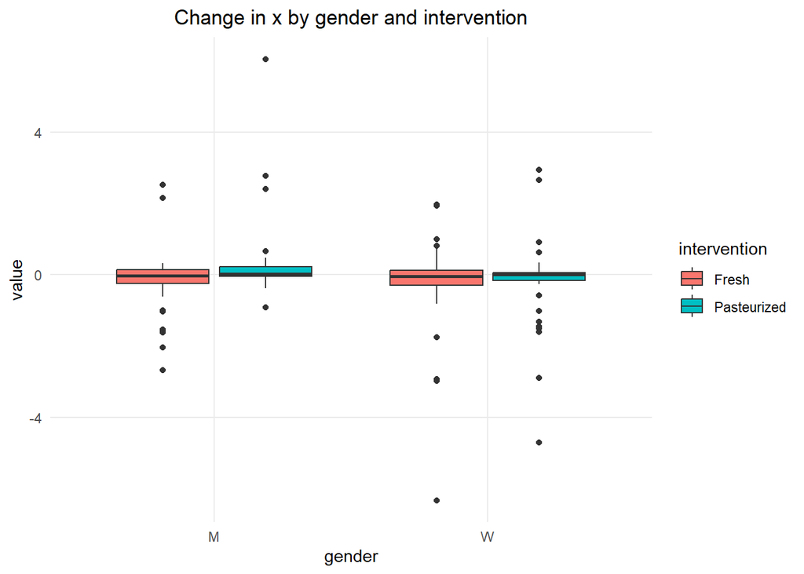

```r
# data preparation
dat_modelX <- dat_change %>%
  select(participant_id, starts_with("xChange")) %>%
  pivot_longer(cols = starts_with("xChange"), names_to = "parameter") %>%
  filter(grepl("T1toT2", parameter) | grepl("T3toT4", parameter),
         !is.na(value)) %>%
  dplyr::left_join(dat %>% distinct(participant_id, .keep_all = TRUE) %>% select(participant_id, gender, age, bmi_t0),
                   by = "participant_id") %>%
  mutate(timepoint = substr(parameter, nchar(parameter) - 1, nchar(parameter))) %>%
  dplyr::left_join(dat %>% select(participant_id, timepoint, intervention),
                   by = c("participant_id", "timepoint"))

# description
ggplot(dat_modelX, aes(x = gender, y = value, fill = intervention)) +
  geom_boxplot() +
  ggtitle("Change in x by gender and intervention")
```

```r
# model estimation
mX <- gam(value ~ intervention*gender + age + bmi_t0 + s(participant_id, bs = "re"),
          data = dat_modelX)

# results
APCtools::create_modelSummary(list(mX))[[1]] %>% kable_styling()
```

| model | param | coef | se | CI_lower | CI_upper | pvalue |
| --- | --- | --- | --- | --- | --- | --- |
| model 1 | (Intercept) | -0.54 | 0.81 | -2.12 | 1.04 | - |
| model 1 | interventionPasteurized | 0.52 | 0.26 | 0.01 | 1.03 | 0.048 |
| model 1 | genderW | -0.02 | 0.25 | -0.52 | 0.47 | 0.9286 |
| model 1 | age | 0.00 | 0.01 | -0.01 | 0.01 | 0.8607 |
| model 1 | bmi_t0 | 0.01 | 0.03 | -0.05 | 0.07 | 0.706 |
| model 1 | interventionPasteurized:genderW | -0.44 | 0.35 | -1.12 | 0.23 | 0.2015 |

## Model on y change

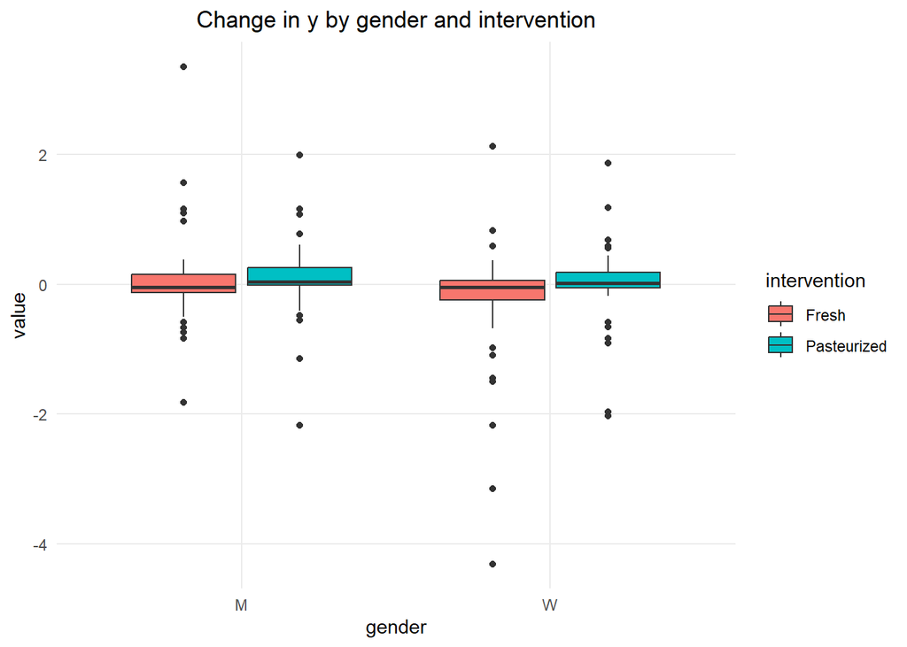

```r
# data preparation
dat_modelY <- dat_change %>%
  select(participant_id, starts_with("yChange")) %>%
  pivot_longer(cols = starts_with("yChange"), names_to = "parameter") %>%
  filter(grepl("T1toT2", parameter) | grepl("T3toT4", parameter),
         !is.na(value)) %>%
  dplyr::left_join(dat %>% distinct(participant_id, .keep_all = TRUE) %>% select(participant_id, gender, age, bmi_t0),
                   by = "participant_id") %>%
  mutate(timepoint = substr(parameter, nchar(parameter) - 1, nchar(parameter))) %>%
  dplyr::left_join(dat %>% select(participant_id, timepoint, intervention),
                   by = c("participant_id", "timepoint"))

# description
ggplot(dat_modelY, aes(x = gender, y = value, fill = intervention)) +
  geom_boxplot() +
  ggtitle("Change in y by gender and intervention")
```

```r
# model estimation
mY <- gam(value ~ intervention*gender + age + bmi_t0 + s(participant_id, bs = "re"),
          data = dat_modelY)

# results
APCtools::create_modelSummary(list(mY))[[1]] %>% kable_styling()
```

| model | param | coef | se | CI_lower | CI_upper | pvalue |
| --- | --- | --- | --- | --- | --- | --- |
| model 1 | (Intercept) | -0.23 | 0.55 | -1.32 | 0.86 | - |
| model 1 | interventionPasteurized | 0.00 | 0.18 | -0.35 | 0.35 | 0.994 |
| model 1 | genderW | -0.34 | 0.17 | -0.68 | 0.00 | 0.0506 |
| model 1 | age | 0.00 | 0.00 | -0.01 | 0.01 | 0.6922 |
| model 1 | bmi_t0 | 0.01 | 0.02 | -0.03 | 0.05 | 0.6613 |
| model 1 | interventionPasteurized:genderW | 0.28 | 0.24 | -0.18 | 0.75 | 0.2359 |

# Average absolute change against other variables

This section analyses if there are specific conditions that show stronger UMAP coordinate variation. The latter is analyzed in categories: low (0-0.5) / mid (0.5-1) / high (>1) average absolute variation.

```r
dat_catVar <- dat_modelTotal %>%
  mutate(UMAPvar_cat = case_when(value > 1   ~ "high",
                                 value > 0.5 ~ "mid",
                                 TRUE        ~ "low"),
         UMAPvar_cat = factor(UMAPvar_cat, levels = c("low","mid","high")),
         avgAbsBaselineChange_cat = case_when(avgAbsBaselineChange_T1toT3 > 1   ~ "> 1",
                                              avgAbsBaselineChange_T1toT3 > 0.5 ~ "(0.5,1]",
                                              TRUE                              ~ "< 0.5"),
         avgAbsBaselineChange_cat = factor(avgAbsBaselineChange_cat, levels = c("< 0.5", "(0.5,1]", "> 1")))
```

The left plots of the following figures visualize the intra-personal baseline variation, for comparison. Intra-personal baseline variation, based on taking the average of the absolute differences in the x- and y-coordinates between timepoints T1 and T3. We focus on T1 and T3 since people at these both timepoints had similar dietary restrictions. T5 didn’t have these restrictions and this fact alone would influence the difference to T1 / T3.

## Whole sample

### … against gender

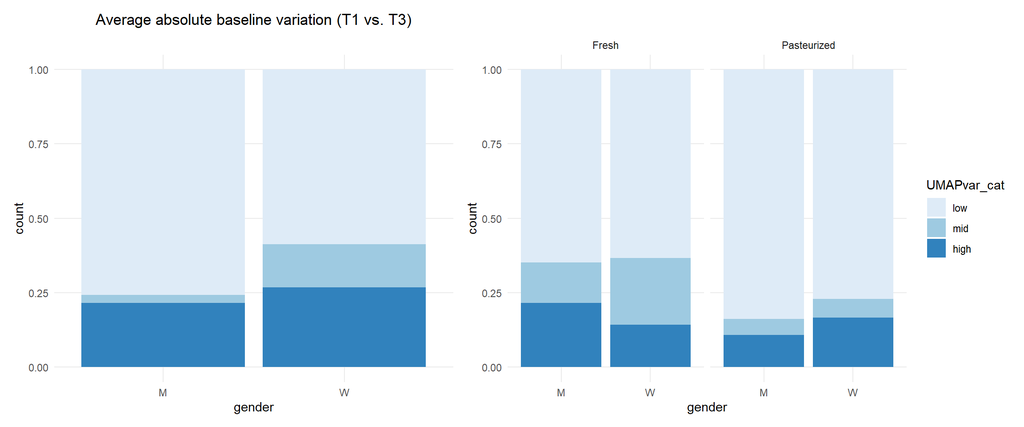

```r
gg_baseline <- dat_catVar %>%
  ggplot(aes(x = gender, fill = avgAbsBaselineChange_cat)) +
  geom_bar(position = "fill") +
  scale_fill_brewer(palette = "Blues") +
  ggtitle("Average absolute baseline variation (T1 vs. T3)")

gg_gender <- dat_catVar %>%
  ggplot(aes(x = gender, fill = UMAPvar_cat)) +
  geom_bar(position = "fill") +
  scale_fill_brewer(palette = "Blues") +
  facet_wrap(~ intervention)

(gg_baseline + theme(legend.position = "none")) + gg_gender
```

### … against age

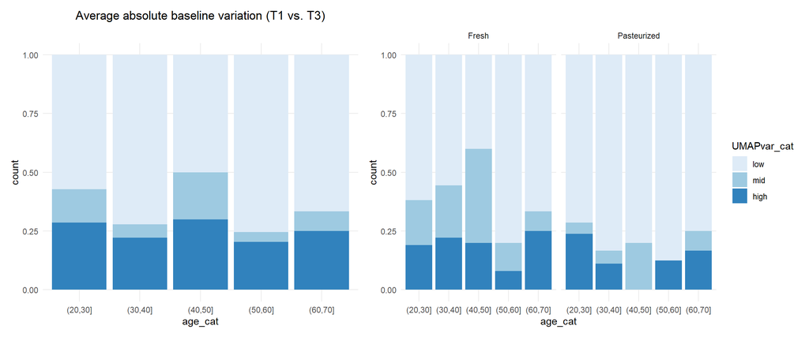

```r
gg_baseline <- dat_catVar %>%
  mutate(age_cat = cut(age, breaks = seq(10, 70, by = 10))) %>%
  ggplot(aes(x = age_cat, fill = avgAbsBaselineChange_cat)) +
  geom_bar(position = "fill") +
  scale_fill_brewer(palette = "Blues") +
  ggtitle("Average absolute baseline variation (T1 vs. T3)")

gg_age <- dat_catVar %>%
  mutate(age_cat = cut(age, breaks = seq(10, 70, by = 10))) %>%
  ggplot(aes(x = age_cat, fill = UMAPvar_cat)) +
  geom_bar(position = "fill") +
  scale_fill_brewer(palette = "Blues") +
  facet_wrap(~ intervention)

(gg_baseline + theme(legend.position = "none")) + gg_age
```

### … against BMI

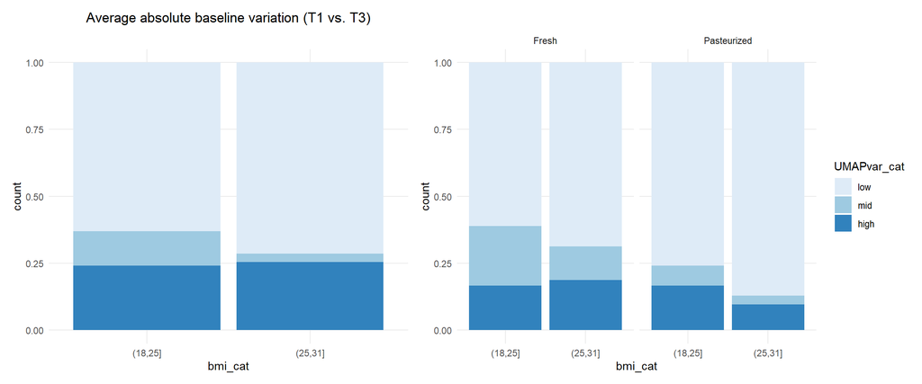

```r
gg_baseline <- dat_catVar %>%
  mutate(bmi_cat = cut(bmi_t0, breaks = c(18,25,31))) %>%
  ggplot(aes(x = bmi_cat, fill = avgAbsBaselineChange_cat)) +
  geom_bar(position = "fill") +
  scale_fill_brewer(palette = "Blues") +
  ggtitle("Average absolute baseline variation (T1 vs. T3)")

gg_bmi <- dat_catVar %>%
  mutate(bmi_cat = cut(bmi_t0, breaks = c(18,25,31))) %>%
  ggplot(aes(x = bmi_cat, fill = UMAPvar_cat)) +
  geom_bar(position = "fill") +
  scale_fill_brewer(palette = "Blues") +
  facet_wrap(~ intervention)

(gg_baseline + theme(legend.position = "none")) + gg_bmi
```

### … against vegetarian diet

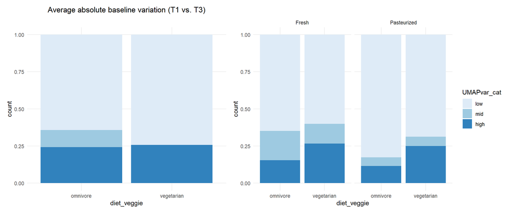

```r
gg_baseline <- dat_catVar %>%
  ggplot(aes(x = diet_veggie, fill = avgAbsBaselineChange_cat)) +
  geom_bar(position = "fill") +
  scale_fill_brewer(palette = "Blues") +
  ggtitle("Average absolute baseline variation (T1 vs. T3)")

gg_veggie <- dat_catVar %>%
  ggplot(aes(x = diet_veggie, fill = UMAPvar_cat)) +
  geom_bar(position = "fill") +
  scale_fill_brewer(palette = "Blues") +
  facet_wrap(~ intervention)

(gg_baseline + theme(legend.position = "none")) + gg_veggie
```

### … against Shannon diversity

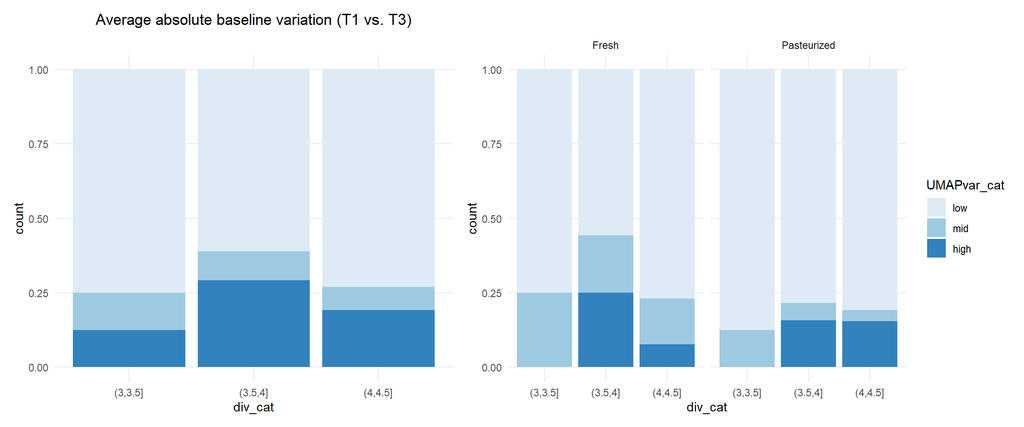

```r
gg_baseline <- dat_catVar %>%
  mutate(div_cat = cut(diversity_shannon, breaks = seq(1, 4.5, by = .5))) %>%
  ggplot(aes(x = div_cat, fill = avgAbsBaselineChange_cat)) +
  geom_bar(position = "fill") +
  scale_fill_brewer(palette = "Blues") +
  ggtitle("Average absolute baseline variation (T1 vs. T3)")

gg_Sdiv <- dat_catVar %>%
  mutate(div_cat = cut(diversity_shannon, breaks = seq(1, 4.5, by = .5))) %>%
  ggplot(aes(x = div_cat, fill = UMAPvar_cat)) +
  geom_bar(position = "fill") +
  scale_fill_brewer(palette = "Blues") +
  facet_wrap(~ intervention)

(gg_baseline + theme(legend.position = "none")) + gg_Sdiv
```

### … against inv. Simpson diversity

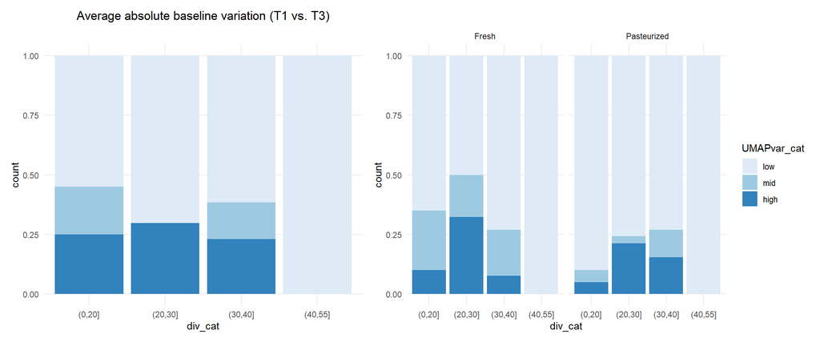

```r
gg_baseline <- dat_catVar %>%
  mutate(div_cat = cut(diversity_invSimpson, breaks = c(0, 20, 30, 40, 55))) %>%
  ggplot(aes(x = div_cat, fill = avgAbsBaselineChange_cat)) +
  geom_bar(position = "fill") +
  scale_fill_brewer(palette = "Blues") +
  ggtitle("Average absolute baseline variation (T1 vs. T3)")

gg_iSdiv <- dat_catVar %>%
  mutate(div_cat = cut(diversity_invSimpson, breaks = c(0, 20, 30, 40, 55))) %>%
  ggplot(aes(x = div_cat, fill = UMAPvar_cat)) +
  geom_bar(position = "fill") +
  scale_fill_brewer(palette = "Blues") +
  facet_wrap(~ intervention)

(gg_baseline + theme(legend.position = "none")) + gg_iSdiv
```

### … against the dominant species

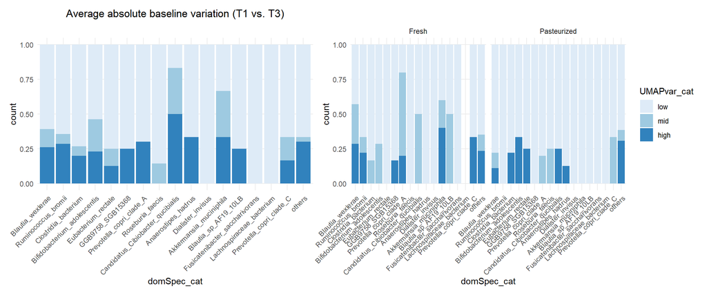

```r
gg_baseline <- dat_catVar %>%
  mutate(domSpec_cat = case_when(dominant_species %in% names(tab_domSpec)[1:16] ~ dominant_species,
                                 TRUE ~ "others"),
         domSpec_cat = factor(domSpec_cat, levels = c(names(tab_domSpec)[1:16], "others"))) %>%
  ggplot(aes(x = domSpec_cat, fill = avgAbsBaselineChange_cat)) +
  geom_bar(position = "fill") +
  scale_fill_brewer(palette = "Blues") +
  ggtitle("Average absolute baseline variation (T1 vs. T3)") +
  theme(axis.text.x = element_text(hjust = 1, angle = 45))

gg_domSp <- dat_catVar %>%
  mutate(domSpec_cat = case_when(dominant_species %in% names(tab_domSpec)[1:16] ~ dominant_species,
                                 TRUE ~ "others"),
         domSpec_cat = factor(domSpec_cat, levels = c(names(tab_domSpec)[1:16], "others"))) %>%
  ggplot(aes(x = domSpec_cat, fill = UMAPvar_cat)) +
  geom_bar(position = "fill") +
  scale_fill_brewer(palette = "Blues") +
  facet_wrap(~ intervention) +
  theme(axis.text.x = element_text(hjust = 1, angle = 45))

(gg_baseline + theme(legend.position = "none")) + gg_domSp
```

### … against the UMAP coordinates

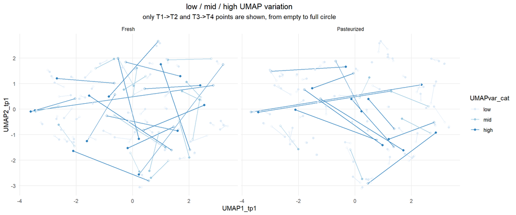

```r
# prepare the data
dat_UMAPplot <- dat_catVar %>%
  dplyr::rename(timepoint_2 = timepoint) %>%
  mutate(timepoint_1 = sapply(parameter, function(x) { strsplit(x, split = "\\_")[[1]][2] %>% substr(1,2) })) %>%
  dplyr::left_join(dat_UMAP %>% select(participant_id, timepoint, UMAP1, UMAP2),
                   by = c("participant_id" = "participant_id", "timepoint_1" = "timepoint")) %>%
  dplyr::rename(UMAP1_tp1 = UMAP1,
                UMAP2_tp1 = UMAP2) %>%
  dplyr::left_join(dat_UMAP %>% select(participant_id, timepoint, UMAP1, UMAP2),
                   by = c("participant_id" = "participant_id", "timepoint_2" = "timepoint")) %>%
  dplyr::rename(UMAP1_tp2 = UMAP1,
                UMAP2_tp2 = UMAP2)

# UMAP plot
ggplot(dat_UMAPplot) +
  geom_segment(aes(x = UMAP1_tp1, y = UMAP2_tp1, xend = UMAP1_tp2, yend = UMAP2_tp2, col = UMAPvar_cat)) +
  geom_point(aes(x = UMAP1_tp1, y = UMAP2_tp1, col = UMAPvar_cat), pch = 1) +
  geom_point(aes(x = UMAP1_tp2, y = UMAP2_tp2, col = UMAPvar_cat)) +
  scale_color_brewer(palette = "Blues") +
  facet_wrap(~ intervention) +
  ggtitle("low / mid / high UMAP variation", subtitle = "only T1->T2 and T3->T4 points are shown, from empty to full circle")
```

##### UMAP with personal polygons

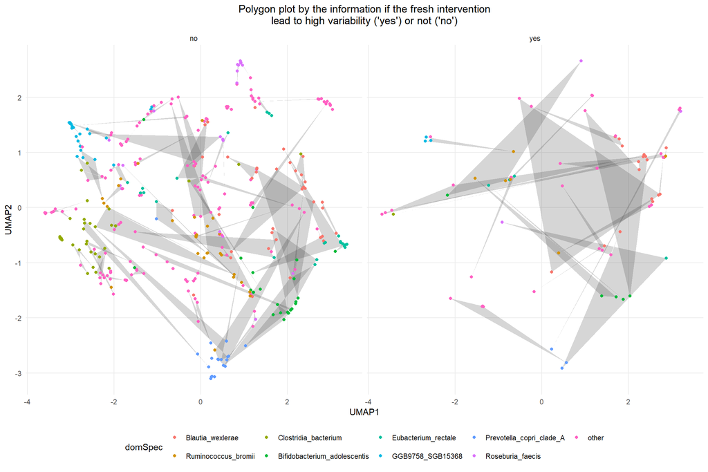

```r
# extract the people with high variability
participants_highVarAfterFresh <- dat_catVar %>%
  filter(intervention == "Fresh",
         UMAPvar_cat  == "high") %>%
  pull(participant_id) %>%
  as.character()
participants_highVarAfterPast <- dat_catVar %>%
  filter(intervention == "Pasteurized",
         UMAPvar_cat  == "high") %>%
  pull(participant_id) %>%
  as.character()

# only focus on the most dominant species
tab_domSpec <- dat$dominant_species %>% table() %>% sort(decreasing = TRUE)

# UMAP plot fresh
dat_UMAP %>%
  mutate(participant_highFreshEffect = case_when(participant_id %in% participants_highVarAfterFresh ~ "yes",
                                                 TRUE ~ "no"),
         participant_highFreshEffect = factor(participant_highFreshEffect),
         domSpec = case_when(dominant_species %in% names(tab_domSpec)[1:8] ~ dominant_species,
                             TRUE ~ "other"),
         domSpec = factor(domSpec, levels = c(names(tab_domSpec)[1:8], "other"))) %>%
  ggplot(aes(x = UMAP1, y = UMAP2)) +
  geom_polygon(aes(group = participant_id), alpha = 0.2) +
  geom_point(aes(col = domSpec)) +
  facet_wrap(~ participant_highFreshEffect) +
  ggtitle("Polygon plot by the information if the fresh intervention\nlead to high variability ('yes') or not ('no')") +
  theme(legend.position = "bottom")
```

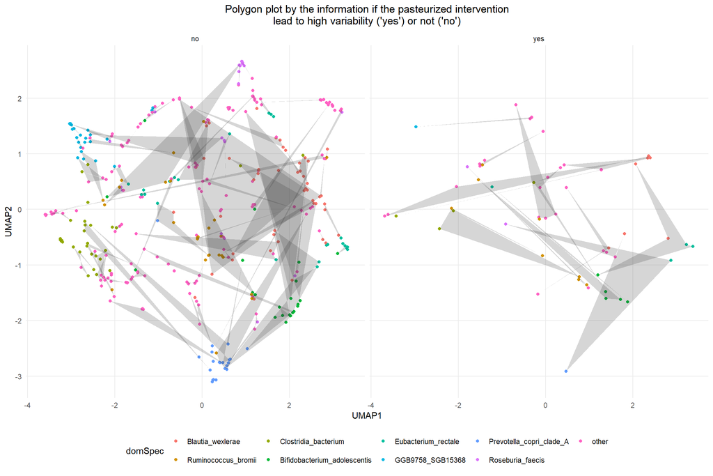

```r
# UMAP plot pasteurized
dat_UMAP %>%
  mutate(participant_highPastEffect = case_when(participant_id %in% participants_highVarAfterPast ~ "yes",
                                                TRUE ~ "no"),
         participant_highPastEffect = factor(participant_highPastEffect),
         domSpec = case_when(dominant_species %in% names(tab_domSpec)[1:8] ~ dominant_species,
                             TRUE ~ "other"),
         domSpec = factor(domSpec, levels = c(names(tab_domSpec)[1:8], "other"))) %>%
  ggplot(aes(x = UMAP1, y = UMAP2)) +
  geom_point(aes(col = domSpec)) +
  geom_polygon(aes(group = participant_id), alpha = 0.2) +
  facet_wrap(~ participant_highPastEffect) +
  ggtitle("Polygon plot by the information if the pasteurized intervention\nlead to high variability ('yes') or not ('no')") +
  theme(legend.position = "bottom")
```

## For low/mid/high baseline var. subsamples

Repeat some of the above analyses, additionally differentiating between people with a low (0-0.5) / mid (0.5-1) / high (>1) average absolute baseline variation (T1 vs. T3).

```r
dat_catVar <- dat_catVar %>%
  mutate(baseline_var = case_when(avgAbsBaselineChange_T1toT3 < 0.5 ~ "low",
                                  avgAbsBaselineChange_T1toT3 < 1   ~ "mid",
                                  TRUE                              ~ "high"),
         baseline_var = factor(baseline_var, levels = c("low", "mid", "high")))
```

### distribution of the baseline var. of the subsamples

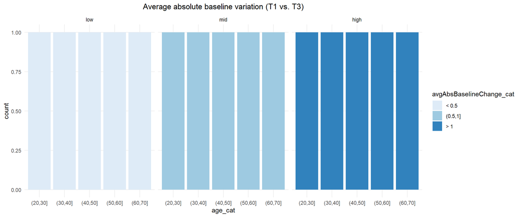

```r
dat_catVar %>%
  mutate(age_cat = cut(age, breaks = seq(10, 70, by = 10))) %>%
  ggplot(aes(x = age_cat, fill = avgAbsBaselineChange_cat)) +
  geom_bar(position = "fill") +
  scale_fill_brewer(palette = "Blues") +
  facet_wrap(~ baseline_var) +
  ggtitle("Average absolute baseline variation (T1 vs. T3)")
```

### … against the baseline variation

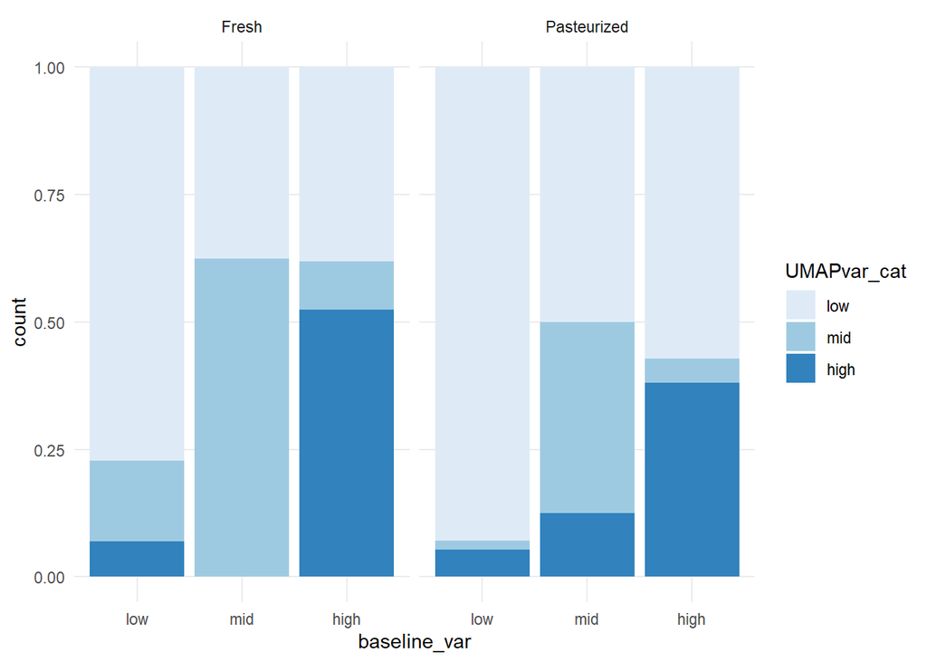

```r
dat_catVar %>%
  ggplot(aes(x = baseline_var, fill = UMAPvar_cat)) +
  geom_bar(position = "fill") +
  scale_fill_brewer(palette = "Blues") +
  facet_grid(cols = vars(intervention))
```

### … against age

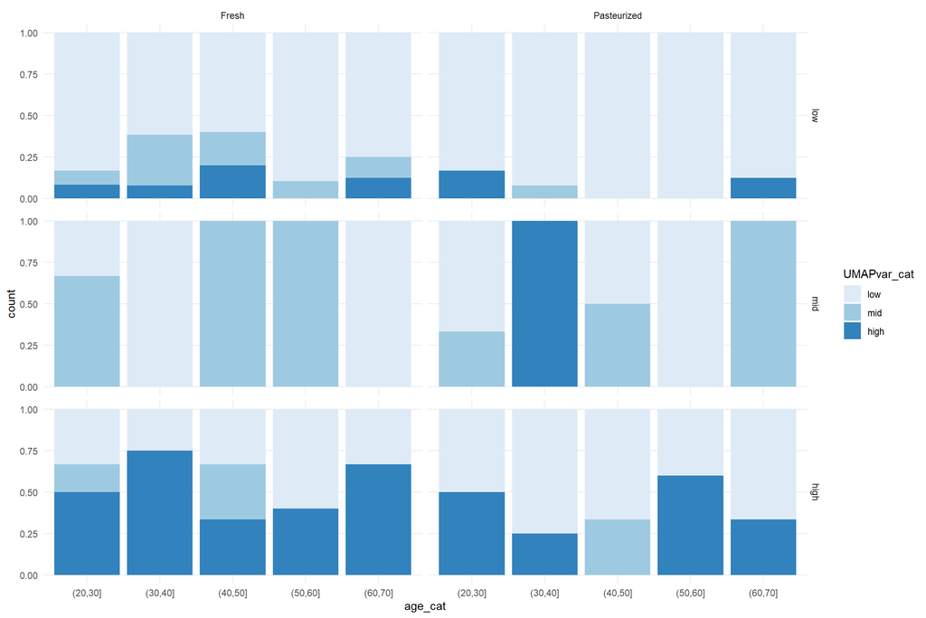

```r
dat_catVar %>%
  mutate(age_cat = cut(age, breaks = seq(10, 70, by = 10))) %>%
  ggplot(aes(x = age_cat, fill = UMAPvar_cat)) +
  geom_bar(position = "fill") +
  scale_fill_brewer(palette = "Blues") +
  facet_grid(rows = vars(baseline_var), cols = vars(intervention))
```

### … against vegetarian diet

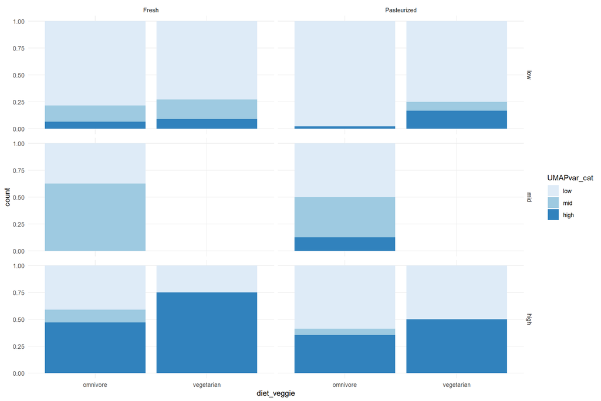

```r
dat_catVar %>%
  ggplot(aes(x = diet_veggie, fill = UMAPvar_cat)) +
  geom_bar(position = "fill") +
  scale_fill_brewer(palette = "Blues") +
  facet_grid(rows = vars(baseline_var), cols = vars(intervention))
```

### … against daily fiber intake

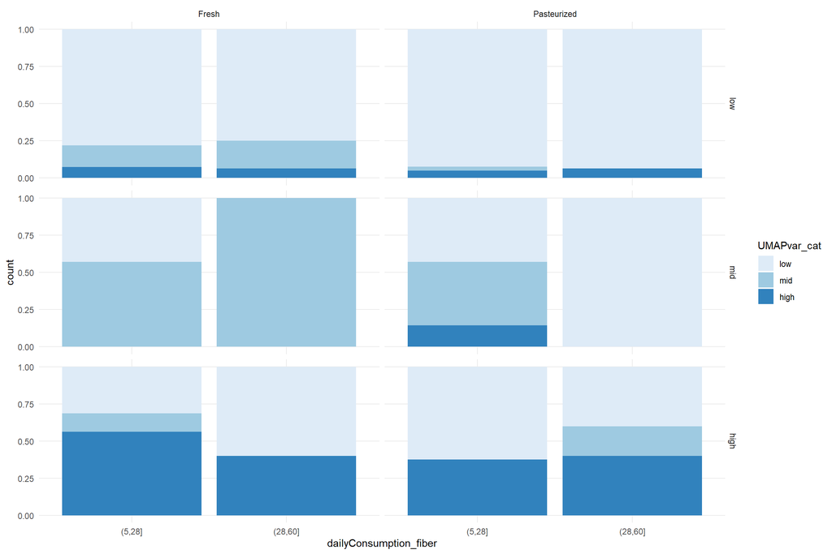

```r
dat_catVar %>%
  mutate(dailyConsumption_fiber = cut(dailyConsumption_fiber, breaks = c(5, 28, 60))) %>%
  ggplot(aes(x = dailyConsumption_fiber, fill = UMAPvar_cat)) +
  geom_bar(position = "fill") +
  scale_fill_brewer(palette = "Blues") +
  facet_grid(rows = vars(baseline_var), cols = vars(intervention))
```

### … against daily fat intake

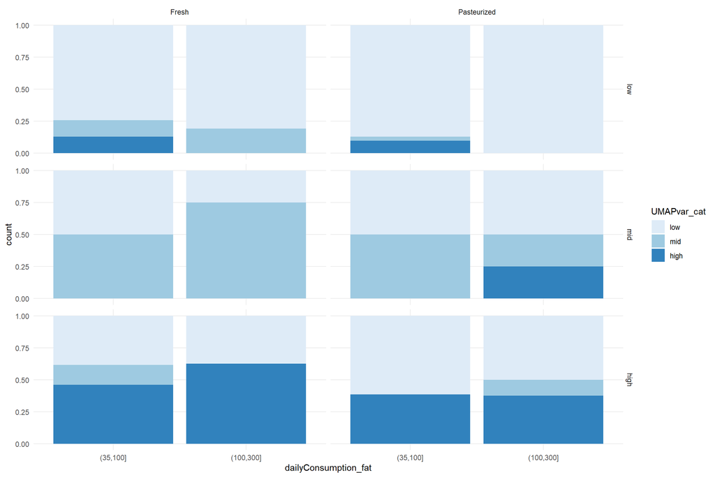

```r
dat_catVar %>%
  mutate(dailyConsumption_fat = cut(dailyConsumption_fat, breaks = c(35, 100, 300))) %>%
  ggplot(aes(x = dailyConsumption_fat, fill = UMAPvar_cat)) +
  geom_bar(position = "fill") +
  scale_fill_brewer(palette = "Blues") +
  facet_grid(rows = vars(baseline_var), cols = vars(intervention))
```

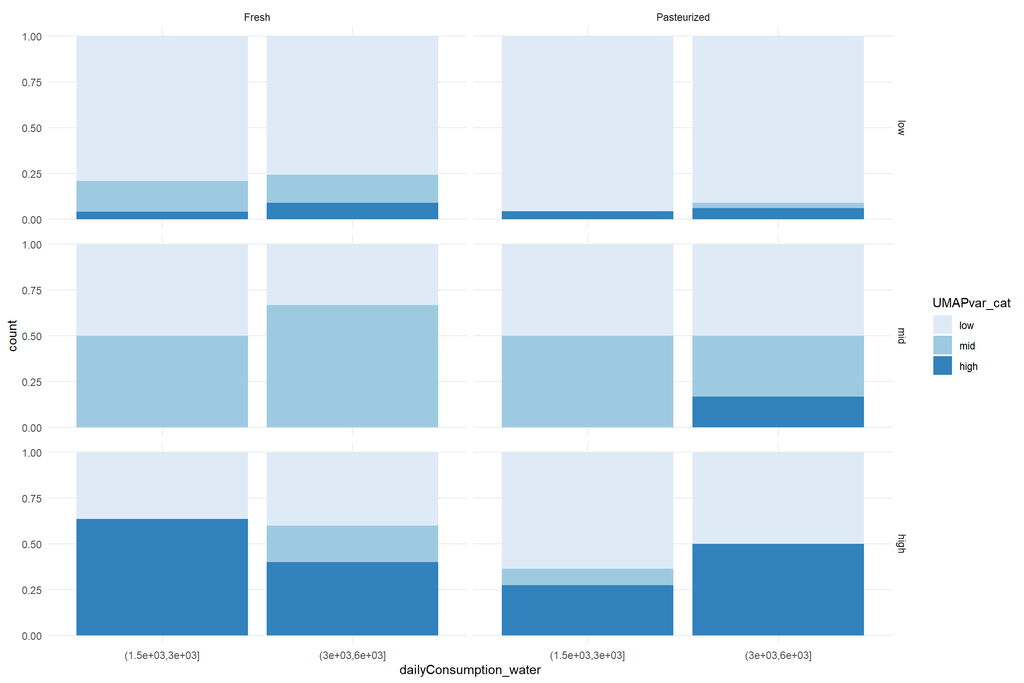

```r
dat_catVar %>%
  mutate(dailyConsumption_water = cut(dailyConsumption_water, breaks = c(1500, 3000, 6000))) %>%
  ggplot(aes(x = dailyConsumption_water, fill = UMAPvar_cat)) +
  geom_bar(position = "fill") +
  scale_fill_brewer(palette = "Blues") +
  facet_grid(rows = vars(baseline_var), cols = vars(intervention))
```

### … against Shannon diversity

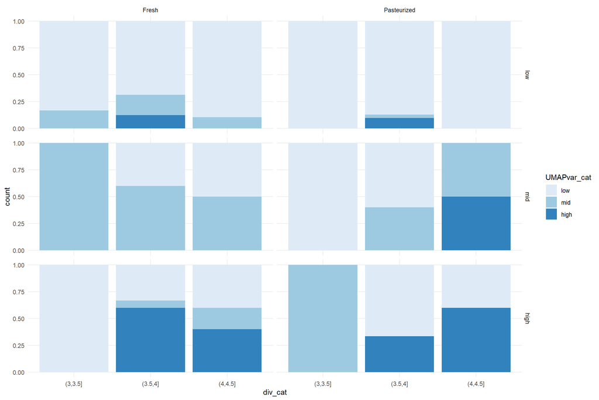

```r
dat_catVar %>%
  mutate(div_cat = cut(diversity_shannon, breaks = seq(1, 4.5, by = .5))) %>%
  ggplot(aes(x = div_cat, fill = UMAPvar_cat)) +
  geom_bar(position = "fill") +
  scale_fill_brewer(palette = "Blues") +
  facet_grid(rows = vars(baseline_var), cols = vars(intervention))
```

### … against inv. Simpson diversity

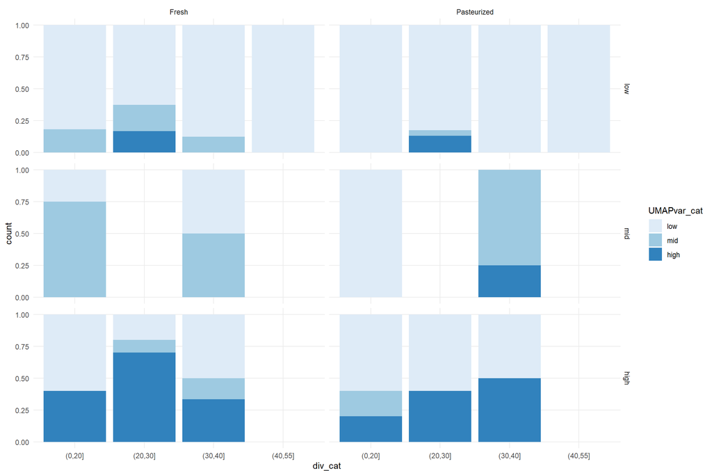

```r
dat_catVar %>%
  mutate(div_cat = cut(diversity_invSimpson, breaks = c(0, 20, 30, 40, 55))) %>%
  ggplot(aes(x = div_cat, fill = UMAPvar_cat)) +
  geom_bar(position = "fill") +
  scale_fill_brewer(palette = "Blues") +
  facet_grid(rows = vars(baseline_var), cols = vars(intervention))
```

### … against the UMAP coordinates

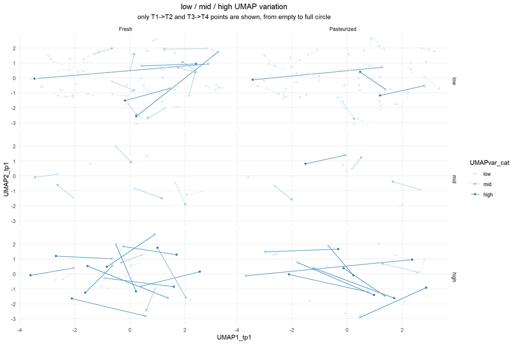

```r
# prepare the data
dat_UMAPplot <- dat_catVar %>%
  dplyr::rename(timepoint_2 = timepoint) %>%
  mutate(timepoint_1 = sapply(parameter, function(x) { strsplit(x, split = "\\_")[[1]][2] %>% substr(1,2) })) %>%
  dplyr::left_join(dat_UMAP %>% select(participant_id, timepoint, UMAP1, UMAP2),
                   by = c("participant_id" = "participant_id", "timepoint_1" = "timepoint")) %>%
  dplyr::rename(UMAP1_tp1 = UMAP1,
                UMAP2_tp1 = UMAP2) %>%
  dplyr::left_join(dat_UMAP %>% select(participant_id, timepoint, UMAP1, UMAP2),
                   by = c("participant_id" = "participant_id", "timepoint_2" = "timepoint")) %>%
  dplyr::rename(UMAP1_tp2 = UMAP1,
                UMAP2_tp2 = UMAP2)

# UMAP plot
ggplot(dat_UMAPplot) +
  geom_segment(aes(x = UMAP1_tp1, y = UMAP2_tp1, xend = UMAP1_tp2, yend = UMAP2_tp2, col = UMAPvar_cat)) +
  geom_point(aes(x = UMAP1_tp1, y = UMAP2_tp1, col = UMAPvar_cat), pch = 1) +
  geom_point(aes(x = UMAP1_tp2, y = UMAP2_tp2, col = UMAPvar_cat)) +
  scale_color_brewer(palette = "Blues") +
  facet_grid(rows = vars(baseline_var), cols = vars(intervention)) +
  ggtitle("low / mid / high UMAP variation", subtitle = "only T1->T2 and T3->T4 points are shown, from empty to full circle")
```